# Model Performance Analysis

Samuel N. Araya

25 June, 2019

# SVR Model Performances

The testing set was split based on random unique combinations of date and transect without replacement into approximately 0.75:0.25 training:testing set split (i.e., 300:100 records).

The testing set was used as a hold-out set and used only to evaluate final trained models. The testing set was subset based on random unique combinations of three sampling dates and two transects without replacement. This method was adopted to ensure that the testing and training samples were not too similar because of spatial autocorrelation, which would result if a simple random splitting was done. Furthermore, to check for possible bias that may result from training:testing set split, we randomly generated 30 unique training-testing set splits and trained 30 models based on the 30 training sets and tested the model performance on their respective testing sets.

## Model Performances Summaries

### Absolute Residual of models sorted by MAE

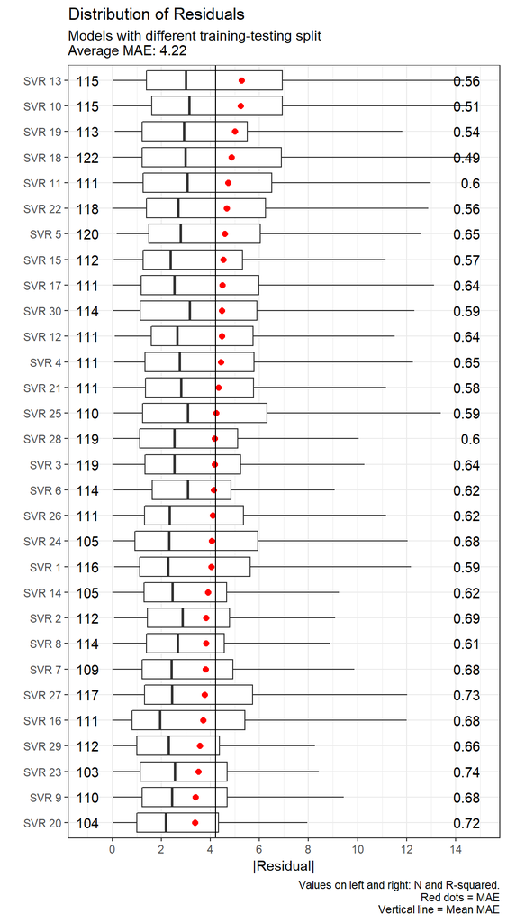

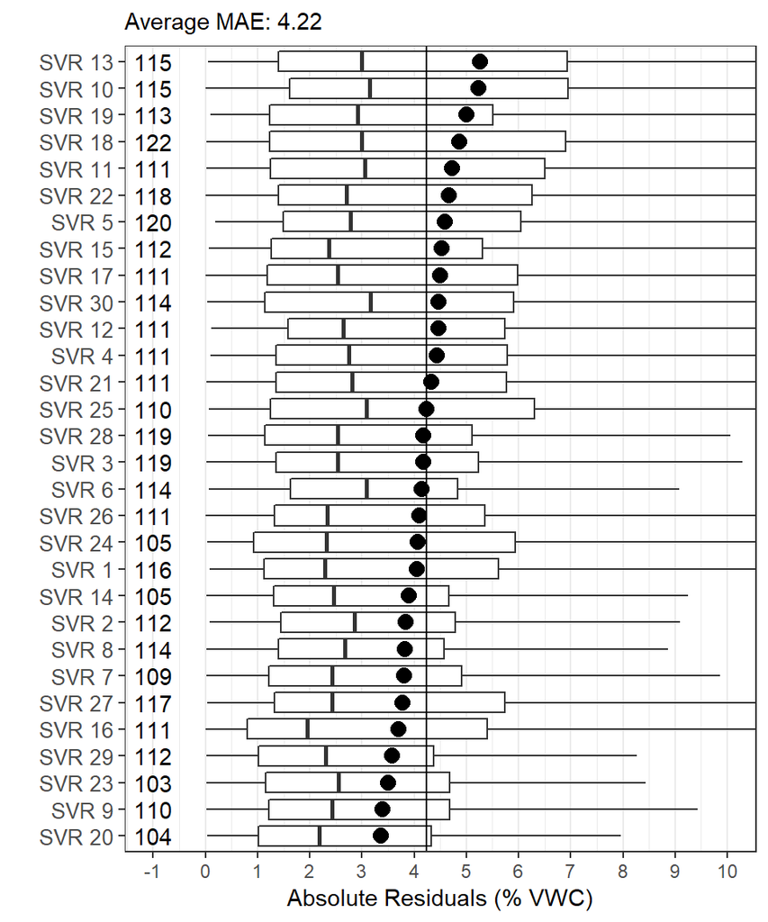

### Predicted vs. Measured Plot

Combined one to one plot with ensemble performance metrics

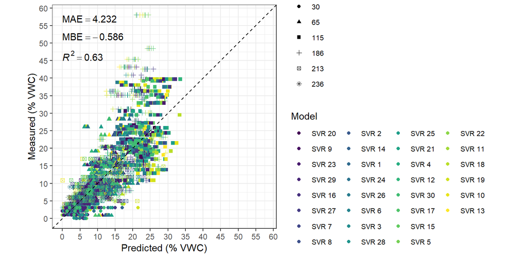

Individual models: Color plot

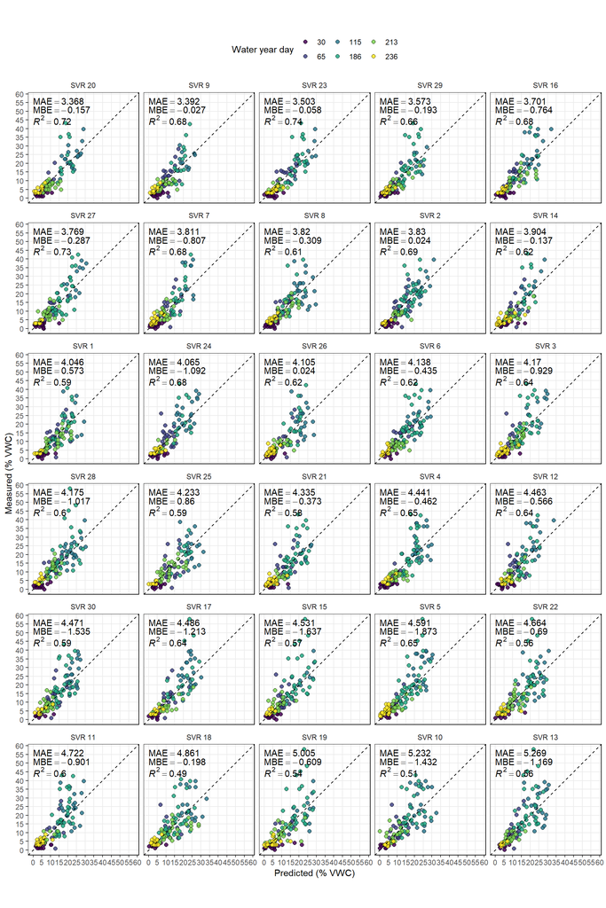

Individual models: Black and white

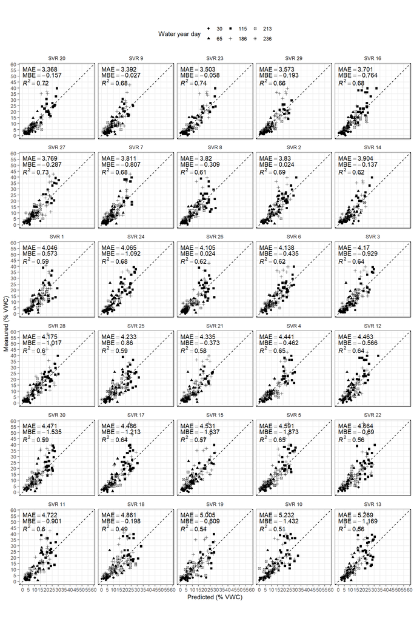

### Variable Importance

Permutation based variable importance calculated as loss from feature dropout.

Top 25 Variables

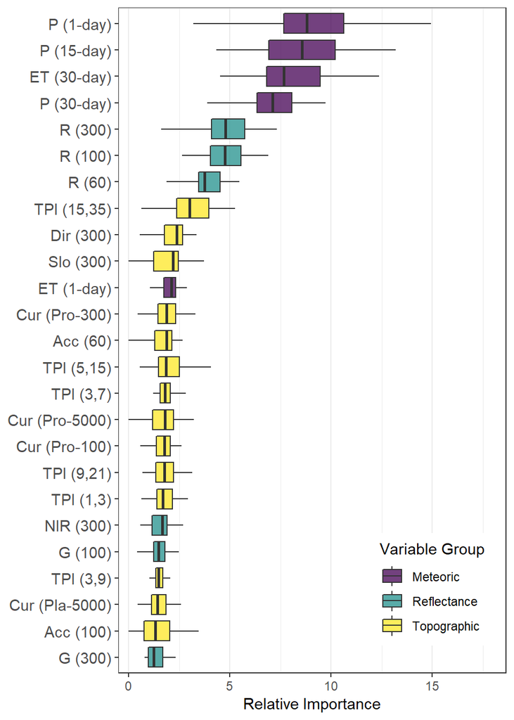

Summation of all variables grouped by type

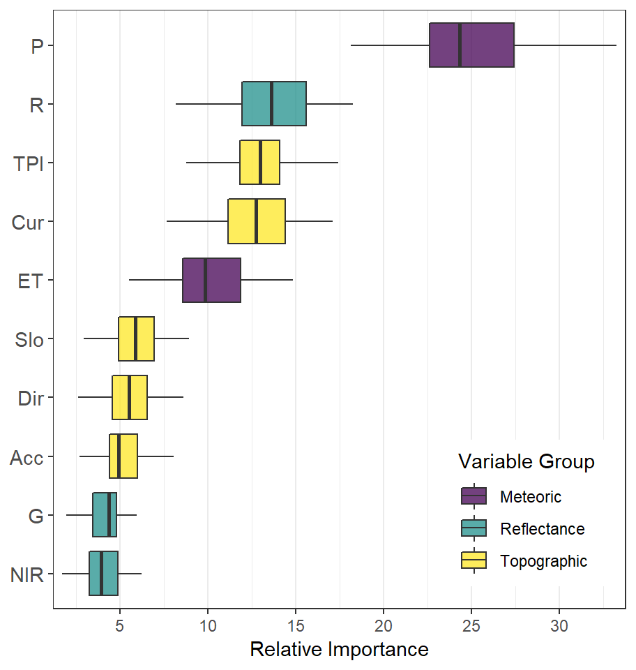

Mean of all variables grouped by type

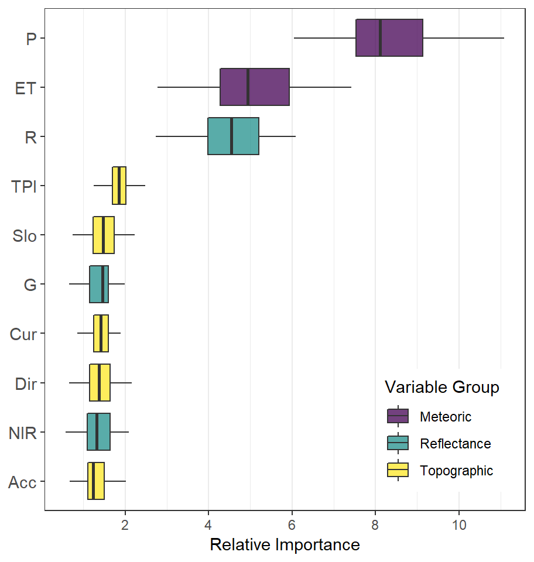

### Variable Effect

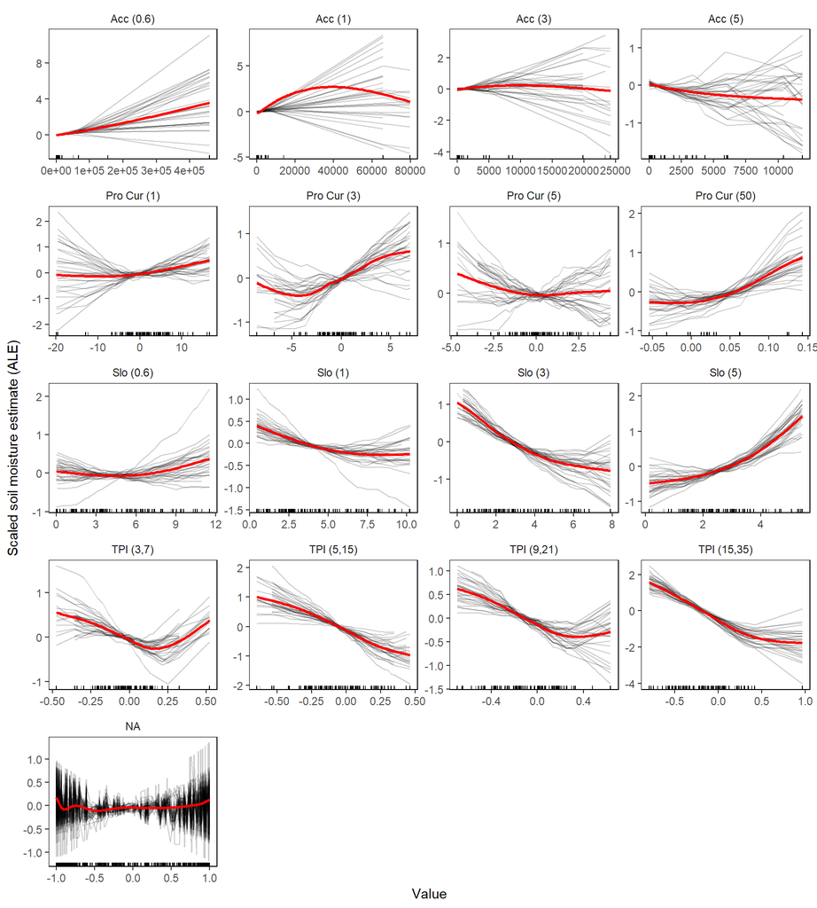

#### Tuning summaries for best models

Best tuning parameters

| id | C | label | label_ordered |
| --- | --- | --- | --- |
| 1 | 1.50 | SVR 1 | SVR 1 |
| 2 | 1.60 | SVR 2 | SVR 2 |
| 3 | 1.50 | SVR 3 | SVR 3 |
| 4 | 1.50 | SVR 4 | SVR 4 |
| 5 | 2.20 | SVR 5 | SVR 5 |
| 6 | 1.80 | SVR 6 | SVR 6 |
| 7 | 1.00 | SVR 7 | SVR 7 |
| 8 | 1.90 | SVR 8 | SVR 8 |
| 9 | 1.00 | SVR 9 | SVR 9 |
| 10 | 3.75 | SVR 10 | SVR 10 |
| 11 | 1.10 | SVR 11 | SVR 11 |
| 12 | 1.30 | SVR 12 | SVR 12 |
| 13 | 1.90 | SVR 13 | SVR 13 |
| 14 | 0.80 | SVR 14 | SVR 14 |
| 15 | 2.70 | SVR 15 | SVR 15 |
| 16 | 2.60 | SVR 16 | SVR 16 |
| 17 | 2.90 | SVR 17 | SVR 17 |
| 18 | 5.50 | SVR 18 | SVR 18 |
| 19 | 2.60 | SVR 19 | SVR 19 |
| 20 | 1.00 | SVR 20 | SVR 20 |
| 21 | 1.60 | SVR 21 | SVR 21 |
| 22 | 2.10 | SVR 22 | SVR 22 |
| 23 | 2.30 | SVR 23 | SVR 23 |
| 24 | 1.40 | SVR 24 | SVR 24 |
| 25 | 1.90 | SVR 25 | SVR 25 |
| 26 | 1.10 | SVR 26 | SVR 26 |
| 27 | 1.80 | SVR 27 | SVR 27 |
| 28 | 2.50 | SVR 28 | SVR 28 |
| 29 | 1.60 | SVR 29 | SVR 29 |
| 30 | 1.30 | SVR 30 | SVR 30 |

Tuning plots

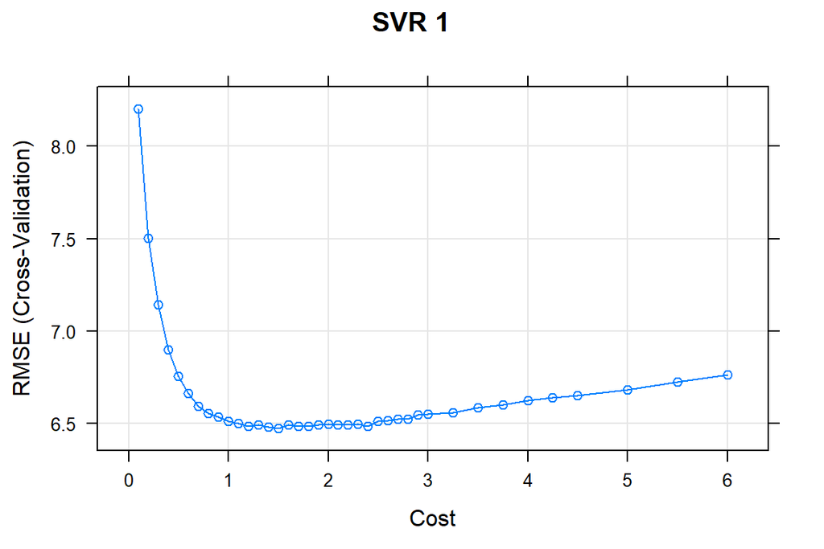

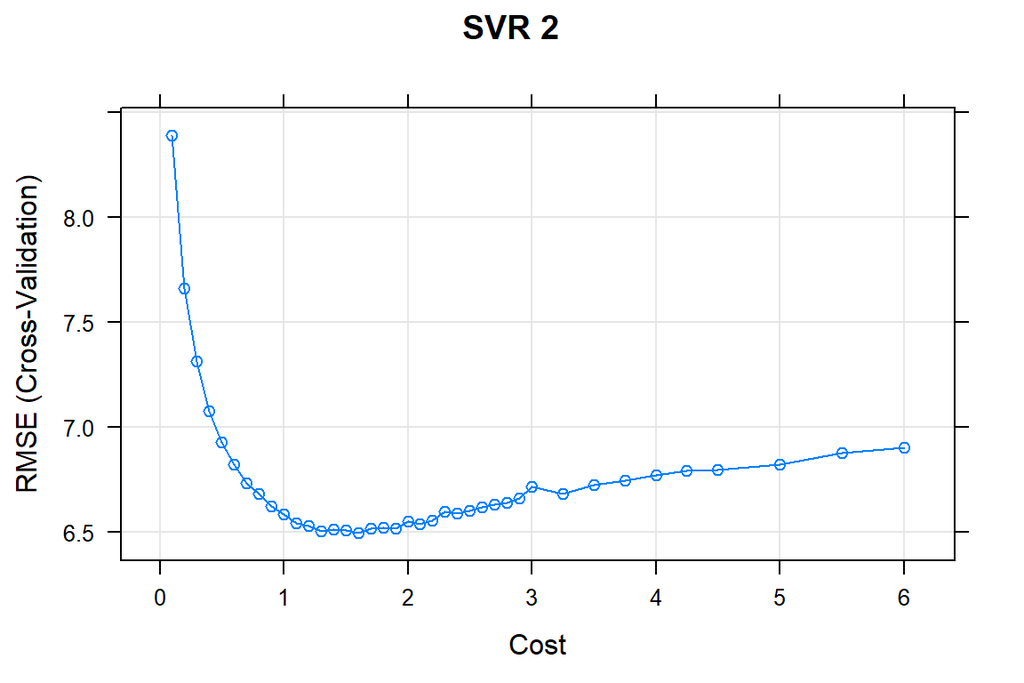

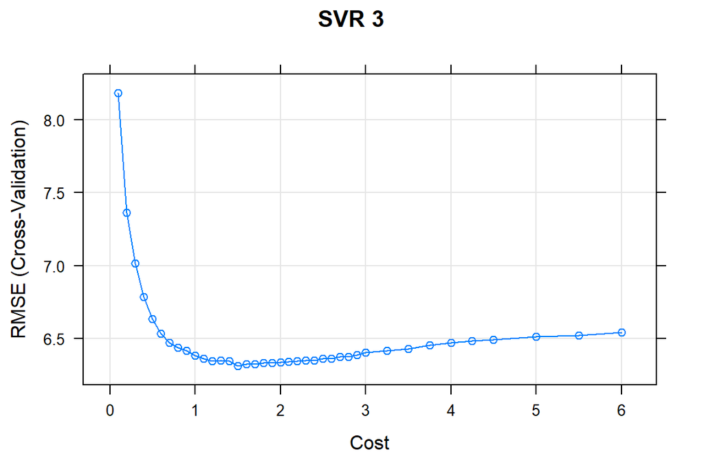

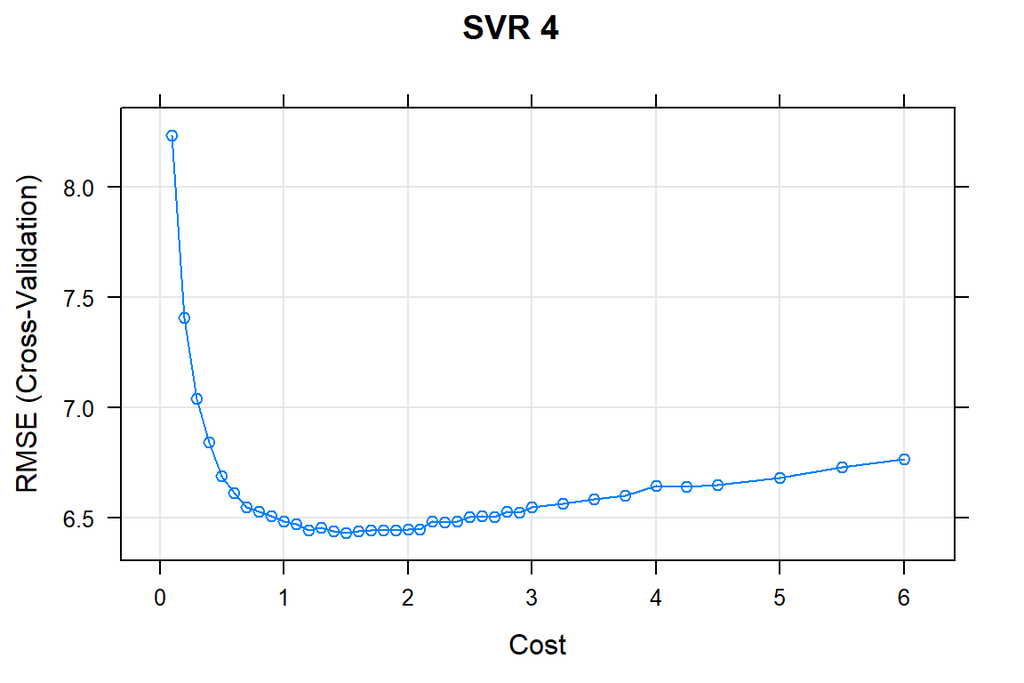

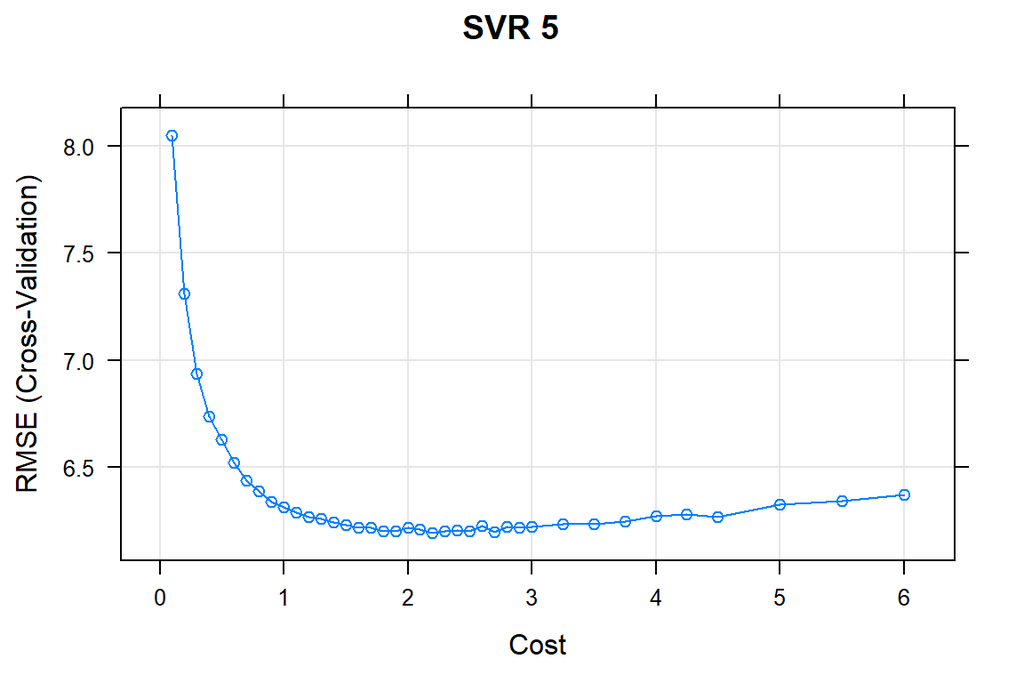

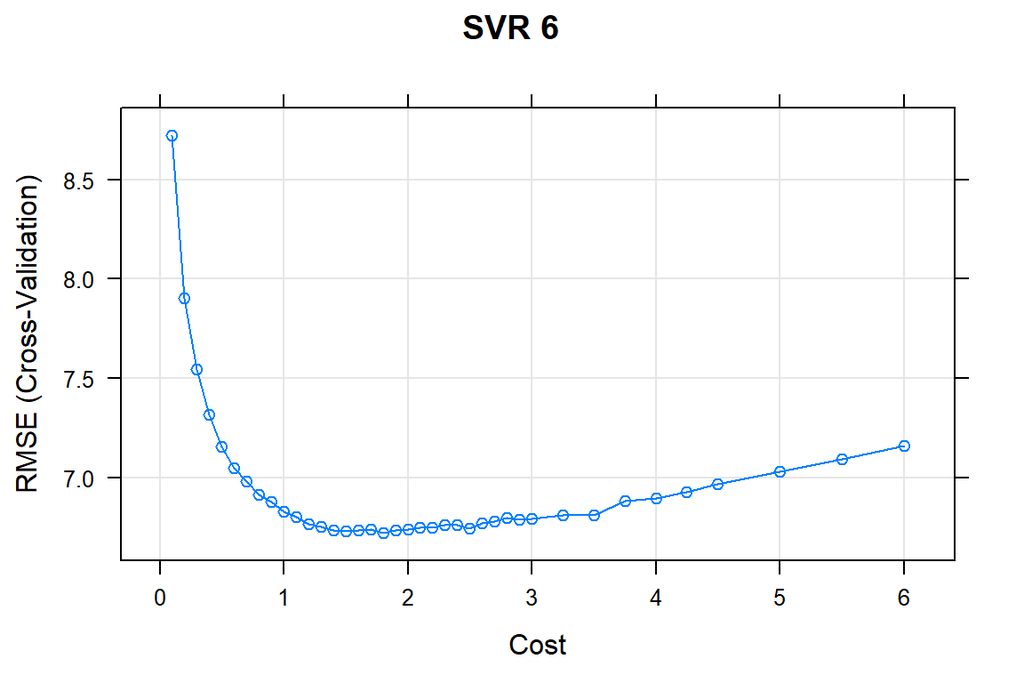

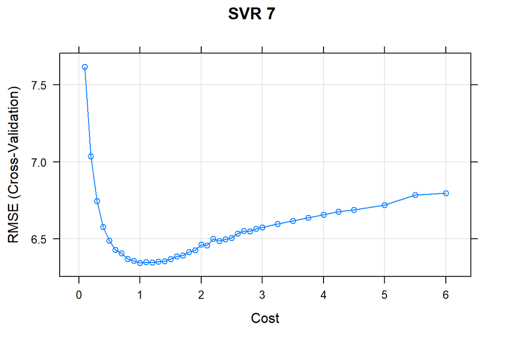

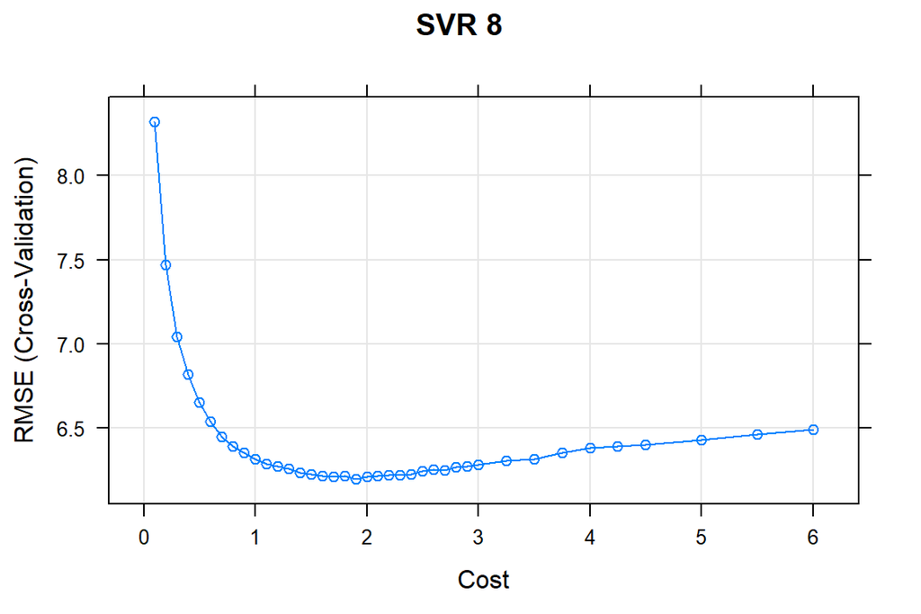

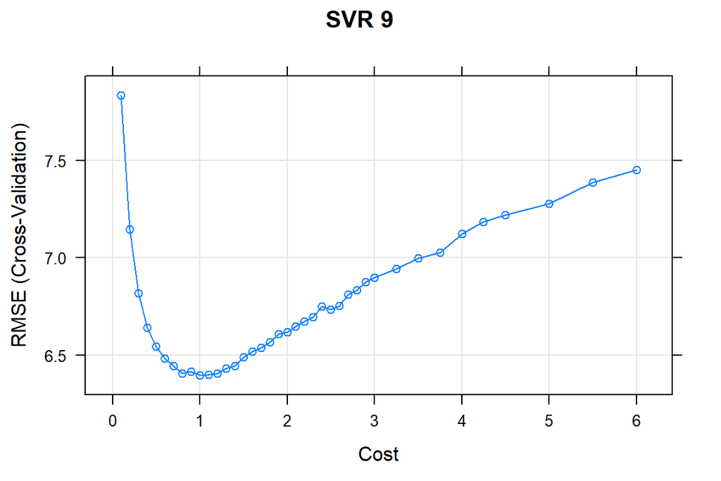

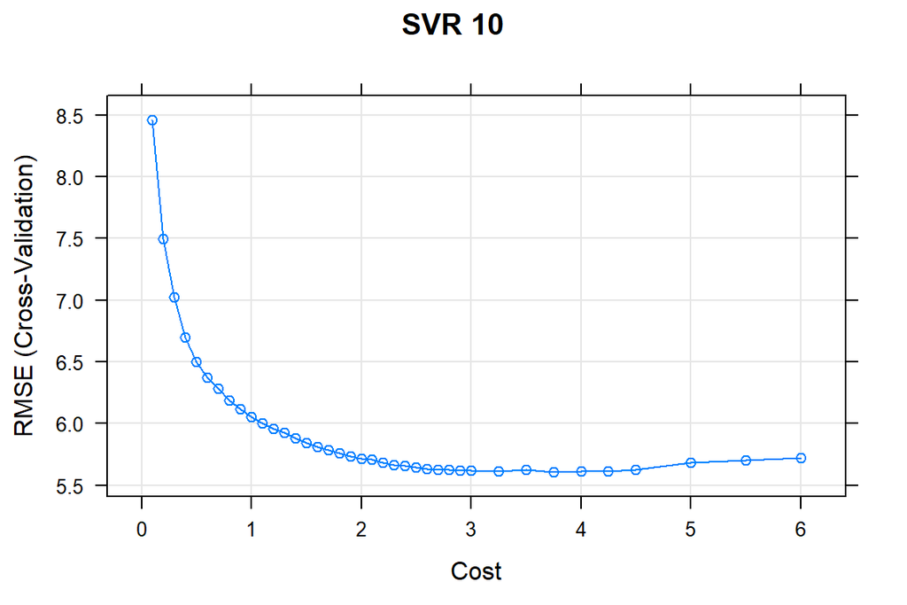

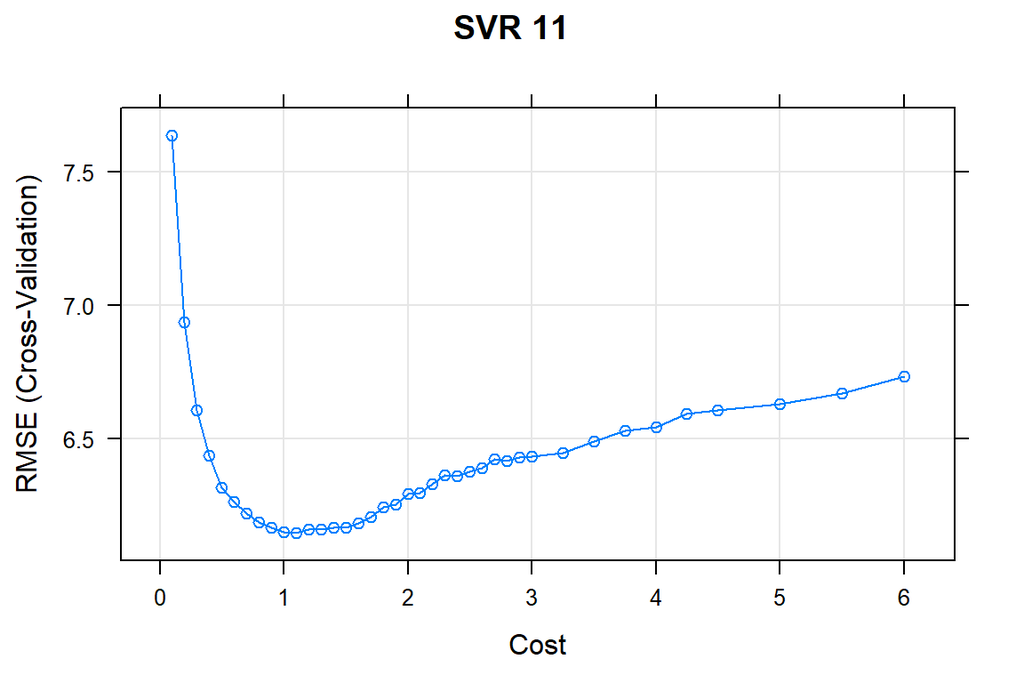

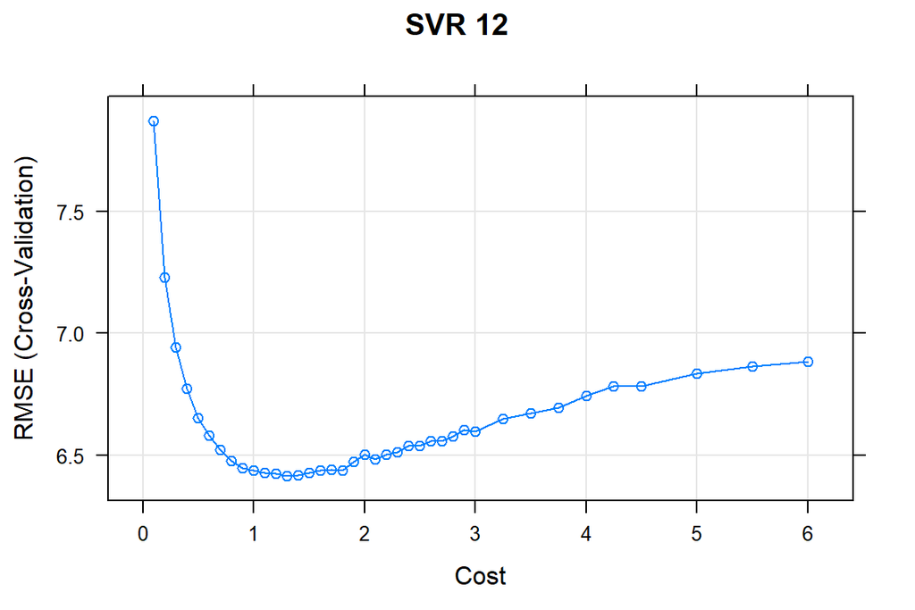

[18 more figures not shown]

## Detailed Model Performances

| label | rmse | mae | mbe | r2 | r2.fmt | n | res_q1 | res_q3 | res_iqr | mae_txt | mbe_txt | r2_txt | label_ordered |
| --- | --- | --- | --- | --- | --- | --- | --- | --- | --- | --- | --- | --- | --- |
| SVR 1 | 5.7705 | 4.0458 | 0.5733 | 0.5912 | 0.59 | 116 | -1.5613 | 3.2042 | 4.7655 | MAE==4.046 | MBE==0.573 | italic(R) ^ 2 == 0.59 | SVR 1 |
| SVR 10 | 7.5024 | 5.2316 | -1.4318 | 0.5096 | 0.51 | 115 | -4.7861 | 2.4632 | 7.2493 | MAE==5.232 | MBE==-1.432 | italic(R) ^ 2 == 0.51 | SVR 10 |
| SVR 11 | 6.9847 | 4.7215 | -0.9007 | 0.5971 | 0.60 | 111 | -2.9624 | 3.0294 | 5.9918 | MAE==4.722 | MBE==-0.901 | italic(R) ^ 2 == 0.6 | SVR 11 |
| SVR 12 | 6.1983 | 4.4634 | -0.5661 | 0.6399 | 0.64 | 111 | -2.7830 | 2.5019 | 5.2848 | MAE==4.463 | MBE==-0.566 | italic(R) ^ 2 == 0.64 | SVR 12 |
| SVR 13 | 8.1162 | 5.2693 | -1.1686 | 0.5572 | 0.56 | 115 | -3.2669 | 2.7766 | 6.0434 | MAE==5.269 | MBE==-1.169 | italic(R) ^ 2 == 0.56 | SVR 13 |
| SVR 14 | 5.7724 | 3.9038 | -0.1367 | 0.6222 | 0.62 | 105 | -1.7446 | 3.0325 | 4.7771 | MAE==3.904 | MBE==-0.137 | italic(R) ^ 2 == 0.62 | SVR 14 |
| SVR 15 | 7.4274 | 4.5313 | -1.6367 | 0.5709 | 0.57 | 112 | -2.7705 | 2.0887 | 4.8592 | MAE==4.531 | MBE==-1.637 | italic(R) ^ 2 == 0.57 | SVR 15 |
| SVR 16 | 5.6825 | 3.7010 | -0.7637 | 0.6820 | 0.68 | 111 | -2.0480 | 1.7311 | 3.7790 | MAE==3.701 | MBE==-0.764 | italic(R) ^ 2 == 0.68 | SVR 16 |
| SVR 17 | 6.9852 | 4.4859 | -1.2134 | 0.6422 | 0.64 | 111 | -2.6051 | 2.4404 | 5.0455 | MAE==4.486 | MBE==-1.213 | italic(R) ^ 2 == 0.64 | SVR 17 |
| SVR 18 | 6.9776 | 4.8607 | -0.1984 | 0.4857 | 0.49 | 122 | -2.4326 | 3.5348 | 5.9674 | MAE==4.861 | MBE==-0.198 | italic(R) ^ 2 == 0.49 | SVR 18 |
| SVR 19 | 7.8151 | 5.0047 | -0.6093 | 0.5373 | 0.54 | 113 | -2.5321 | 3.0318 | 5.5639 | MAE==5.005 | MBE==-0.609 | italic(R) ^ 2 == 0.54 | SVR 19 |
| SVR 2 | 5.2788 | 3.8299 | 0.0243 | 0.6879 | 0.69 | 112 | -2.2095 | 3.1376 | 5.3472 | MAE==3.83 | MBE==0.024 | italic(R) ^ 2 == 0.69 | SVR 2 |
| SVR 20 | 5.1910 | 3.3678 | -0.1569 | 0.7213 | 0.72 | 104 | -1.7755 | 2.4674 | 4.2428 | MAE==3.368 | MBE==-0.157 | italic(R) ^ 2 == 0.72 | SVR 20 |
| SVR 21 | 6.3074 | 4.3347 | -0.3730 | 0.5806 | 0.58 | 111 | -2.0317 | 3.1691 | 5.2007 | MAE==4.335 | MBE==-0.373 | italic(R) ^ 2 == 0.58 | SVR 21 |
| SVR 22 | 7.2919 | 4.6643 | -0.6897 | 0.5555 | 0.56 | 118 | -2.9816 | 2.5375 | 5.5191 | MAE==4.664 | MBE==-0.69 | italic(R) ^ 2 == 0.56 | SVR 22 |
| SVR 23 | 5.1005 | 3.5034 | -0.0578 | 0.7367 | 0.74 | 103 | -1.9040 | 3.0743 | 4.9783 | MAE==3.503 | MBE==-0.058 | italic(R) ^ 2 == 0.74 | SVR 23 |
| SVR 24 | 6.0308 | 4.0649 | -1.0915 | 0.6796 | 0.68 | 105 | -3.1166 | 2.0873 | 5.2040 | MAE==4.065 | MBE==-1.092 | italic(R) ^ 2 == 0.68 | SVR 24 |
| SVR 25 | 5.7206 | 4.2327 | 0.8595 | 0.5928 | 0.59 | 110 | -1.5000 | 3.8896 | 5.3896 | MAE==4.233 | MBE==0.86 | italic(R) ^ 2 == 0.59 | SVR 25 |
| SVR 26 | 5.9162 | 4.1053 | 0.0244 | 0.6188 | 0.62 | 111 | -2.1895 | 2.5809 | 4.7704 | MAE==4.105 | MBE==0.024 | italic(R) ^ 2 == 0.62 | SVR 26 |
| SVR 27 | 5.2516 | 3.7688 | -0.2870 | 0.7261 | 0.73 | 117 | -2.5767 | 2.3879 | 4.9646 | MAE==3.769 | MBE==-0.287 | italic(R) ^ 2 == 0.73 | SVR 27 |
| SVR 28 | 6.7367 | 4.1749 | -1.0169 | 0.5973 | 0.60 | 119 | -2.5887 | 2.5061 | 5.0949 | MAE==4.175 | MBE==-1.017 | italic(R) ^ 2 == 0.6 | SVR 28 |
| SVR 29 | 5.5303 | 3.5735 | -0.1934 | 0.6628 | 0.66 | 112 | -1.5921 | 2.7475 | 4.3396 | MAE==3.573 | MBE==-0.193 | italic(R) ^ 2 == 0.66 | SVR 29 |
| SVR 3 | 6.1298 | 4.1701 | -0.9285 | 0.6430 | 0.64 | 119 | -2.5355 | 2.4386 | 4.9742 | MAE==4.17 | MBE==-0.929 | italic(R) ^ 2 == 0.64 | SVR 3 |
| SVR 30 | 6.4981 | 4.4712 | -1.5351 | 0.5918 | 0.59 | 114 | -3.9956 | 2.4584 | 6.4540 | MAE==4.471 | MBE==-1.535 | italic(R) ^ 2 == 0.59 | SVR 30 |
| SVR 4 | 6.4692 | 4.4411 | -0.4625 | 0.6504 | 0.65 | 111 | -2.3003 | 3.1341 | 5.4343 | MAE==4.441 | MBE==-0.462 | italic(R) ^ 2 == 0.65 | SVR 4 |
| SVR 5 | 7.0862 | 4.5912 | -1.8729 | 0.6524 | 0.65 | 120 | -3.0622 | 2.2255 | 5.2877 | MAE==4.591 | MBE==-1.873 | italic(R) ^ 2 == 0.65 | SVR 5 |
| SVR 6 | 5.8746 | 4.1379 | -0.4355 | 0.6221 | 0.62 | 114 | -2.7526 | 3.4078 | 6.1604 | MAE==4.138 | MBE==-0.435 | italic(R) ^ 2 == 0.62 | SVR 6 |
| SVR 7 | 5.5213 | 3.8113 | -0.8067 | 0.6802 | 0.68 | 109 | -2.2909 | 2.4203 | 4.7111 | MAE==3.811 | MBE==-0.807 | italic(R) ^ 2 == 0.68 | SVR 7 |
| SVR 8 | 5.5982 | 3.8197 | -0.3086 | 0.6058 | 0.61 | 114 | -2.6241 | 2.6476 | 5.2718 | MAE==3.82 | MBE==-0.309 | italic(R) ^ 2 == 0.61 | SVR 8 |
| SVR 9 | 4.7838 | 3.3921 | -0.0272 | 0.6765 | 0.68 | 110 | -1.9311 | 2.7177 | 4.6488 | MAE==3.392 | MBE==-0.027 | italic(R) ^ 2 == 0.68 | SVR 9 |